# host_blood analysis

This notebook assess mosquito blood meal sources

Data description

An experiment was conducted in Tulizamoyo to to assess the proportion of two Anopheles mosquito Species: An. funestus and An. arabiensis (species), blood feeding on vertebrates (host_blood). The experiment was done in a field setting, and mosquitoes were collected in different houses (hh_id), using different traps (trap_method), indoors and outdoors (position). PCR targeting cytocrome b was performed on the samples collected, and the number of amplified samples were recorded (count).

Key question: What type of host do anopheles mosquitoes prefer to feed on, when the host availability is almost 50/50?

```r
rm(list = ls())
# list.files()
```

Load all required packages

```r
library(lme4, warn.conflicts = FALSE) # for generalized linear mixed effect models
library(MASS, warn.conflicts = FALSE) # for generalized models
suppressWarnings(library(tidyverse, warn.conflicts = FALSE)) # for data cleaning and manipulation
library(data.table, v) # import data table package to factor Xticks
library(ggplot2, warn.conflicts = FALSE) # for plotting
library(effects, warn.conflicts = FALSE)
library(ggeffects, warn.conflicts = FALSE)
library(sjPlot, warn.conflicts = FALSE)
```

load data

```r
# setwd("C:/Mannu/Projects/Mannu Phd/GLM_metadata")
metadata_df <- read.csv("C:/Mannu/Projects/Mannu Phd/GLM_metadata/_blood_meal_metadata_final.csv")

# factor house hold id column
metadata_df[,'hh_id'] <- as.factor(metadata_df[,'hh_id'])

# drop unused column
metadata_df <- select(metadata_df, -X)

# first print to the console all of the unique values you will need to recode)
print(distinct(metadata_df, host_blood))
```

| host_blood |
| --- |
| Bovine |
| Human |
| Dog |
| Human_cow |
| Human_dog |
| Cow_dog |

```r
# view data
glimpse(metadata_df)
```

```
Rows: 88
Columns: 6
$ species     <chr> "arabiensis", "arabiensis", "arabiensis", "arabiensis",…
$ hh_id       <fct> 1, 1, 1, 1, 1, 1, 2, 2, 2, 2, 2, 3, 3, 3, 4, 4, 4, 4, 4…
$ position    <chr> "indoor", "indoor", "indoor", "indoor", "outdoor", "out…
$ trap_method <chr> "CDC", "CDC", "PRK", "RBK", "PRK", "RBK", "CDC", "PRK",…
$ host_blood  <chr> "Bovine", "Human", "Bovine", "Bovine", "Bovine", "Bovin…
$ count       <int> 4, 1, 14, 1, 1, 55, 6, 4, 3, 2, 22, 1, 1, 34, 2, 3, 1, …
```

Recode all cow written factors as bovine

```r
metadata_df$host_blood <- recode(metadata_df$host_blood,
                                      Human_cow = "Human_bovine",
                                      Cow_dog = "Bovine_dog")
metadata_df$host_blood <- factor(metadata_df$host_blood, levels = c("Human",
                                                                    "Bovine",
                                                                    "Dog",
                                                                    "Human_bovine",
                                                                    "Human_dog",
                                                                    "Bovine_dog"))


print(distinct(metadata_df, host_blood))
```

| host_blood |
| --- |
| Bovine |
| Human |
| Dog |
| Human_bovine |
| Human_dog |
| Bovine_dog |

```r
NA
```

Exploring the data and visualizing the data

```r
# table() is a useful function for understanding the study design
# that produced the data set

print(table(metadata_df$host_blood))
```

```
       Human       Bovine          Dog Human_bovine    Human_dog
          20           40           13            9            3
  Bovine_dog
           3
```

```r
print(table(metadata_df$species))
```

```
arabiensis   funestus
        27         61
```

```r
# # mosquito species blood-fed on vertebrate

table(metadata_df$host_blood, metadata_df$species)
```

```
               arabiensis funestus
  Human                 2       18
  Bovine               23       17
  Dog                   2       11
  Human_bovine          0        9
  Human_dog             0        3
  Bovine_dog            0        3
```

Create a summary table for all counts (species & hosts)

```r
sumC <- tapply(metadata_df$count, list(metadata_df$species, metadata_df$host_blood), sum)

# Compile into a dataframe

sum_df = data.frame(sumC)

# Add 0 to replace N/A

sum_df[1, 4] = 0
sum_df[1, 5] = 0
sum_df[1, 6] = 0

sum_df
```

|  | Human | Bovine | Dog | Human_bovine | Human_dog | Bovine_dog |
| --- | --- | --- | --- | --- | --- | --- |
| arabiensis | 2 | 254 | 3 | 0 | 0 | 0 |
| funestus | 167 | 584 | 65 | 26 | 5 | 5 |

```r
# sum_df_2 = sum_df %>%
#                 select(Human, Bovine, Dog)
# sum_df_2
# 1. fisher exact test
# 2. Kruskal-Wallis test (non-parametric version of an anova)
```

1. fisher exact test

The hypotheses of the Fisher’s exact test are the same than for the Chi-square test, that is:

H0 : the variables are independent, there is no relationship between the two categorical variables. Knowing the value of one variable does not help to predict the value of the other variable

H1 : the variables are dependent, there is a relationship between the two categorical variables. Knowing the value of one variable helps to predict the value of the other variable

Start by plotting the mosaic to visually represent the data

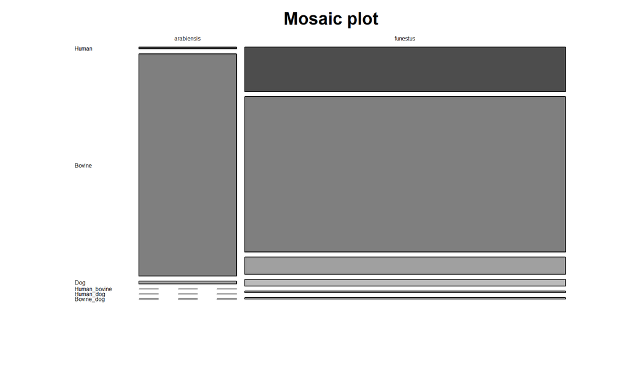

```r
mosaicplot(sum_df,
  main = "Mosaic plot",
  color = TRUE, las = 1, cex.axis = 0.4
)
```

Expected frequencies

Remember that the Fisher’s exact test is used when there is at least one cell in the contingency table of the expected frequencies below 5. To retrieve the expected frequencies, use the chisq.test() function together with $expected:

```r
chisq.test(sum_df)$expected
```

```
               Human   Bovine      Dog Human_bovine Human_dog Bovine_dog
arabiensis  39.39784 195.3573 15.85239     6.061206  1.165617   1.165617
funestus   129.60216 642.6427 52.14761    19.938794  3.834383   3.834383
```

The contingency table above confirms that we should use the Fisher’s exact test instead of the Chi-square test because there is at least one cell below 5.

To perform the Fisher’s exact test in R, use the fisher.test() function as you would do for the Chi-square test:

```r
test = fisher.test(sum_df, workspace = 2e6)
test$p.value
```

```
[1] 8.10627e-26
```

It is possible print the results of the Fisher’s exact test directly on a barplot thanks to the ggbarstats() function from the {ggstatsplot} package (the function has been slightly edited to match our needs).

It is easier to work with the package when our data is not already in the form of a contingency table so we transform it to a data frame before plotting the results:

```r
x <- c()

for (row in rownames(sum_df)) {

  for (col in colnames(sum_df)) {

    x <- rbind(x, matrix(rep(c(row, col), sum_df[row, col]), ncol = 2, byrow = TRUE))

  }

}

df <- as.data.frame(x)

colnames(df) <- c("Species", "Host")

df$Host <- factor(df$Host, levels = c("Human",
                                      "Bovine",
                                      "Dog",
                                      "Human_bovine",
                                      "Human_dog",
                                      "Bovine_dog"))


df
```

| Species | Host |
| --- | --- |
| arabiensis | Human |
| arabiensis | Human |
| arabiensis | Bovine |
| arabiensis | Bovine |
| arabiensis | Bovine |
| arabiensis | Bovine |
| arabiensis | Bovine |
| arabiensis | Bovine |
| arabiensis | Bovine |
| arabiensis | Bovine |

[output cut: 990 more lines]

```r
NA
```

Fisher’s exact test with raw data

```r
# Fisher's exact test with raw data
test <- fisher.test(table(df), workspace = 2e6)
test
```

```
    Fisher's Exact Test for Count Data

data:  table(df)
p-value < 2.2e-16
alternative hypothesis: two.sided
```

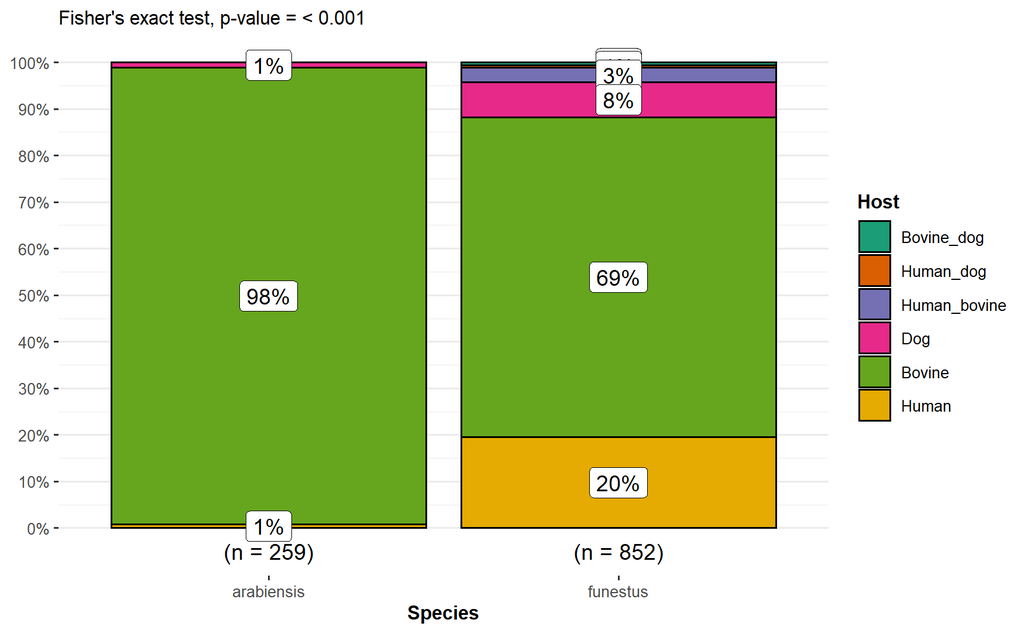

```r
# combine plot and statistical test with ggbarstats
library(ggstatsplot)

ggbarstats(
  df, Host, Species,
  results.subtitle = FALSE,
  subtitle = paste0(
    "Fisher's exact test", ", p-value = ",
    ifelse(test$p.value < 0.001, "< 0.001", round(test$p.value, 3))
  )
)

ggsave("C:/Mannu/Projects/Mannu Phd/GLM_metadata/fishers test.png", dpi = 500)
```

From the plot, it seems that *An. funestus* is more likely feed on human, bovine and dog and even having mixed blood meals, while *An. arabiensis* blood-fed only on bovine, dog, and human. Species and hosts are thus expected to be dependent.

Therefore, here we reject the null hypothesis and we conclude that species and hosts are dependent (p-value < 0.001).

Dropping mixed blood meals

```r
sum_df_2 = sum_df %>%
                select(Human, Bovine, Dog)
sum_df_2
```

|  | Human | Bovine | Dog |
| --- | --- | --- | --- |
| arabiensis | 2 | 254 | 3 |
| funestus | 167 | 584 | 65 |

```r
NA
```

Expected frequencies

Checking if at least one cell in the contingency table of the expected frequencies below 5. To see if we can use Fisher’s exact test or Chi square

```r
chisq.test(sum_df_2)$expected
```

```
               Human   Bovine      Dog
arabiensis  40.71721 201.8995 16.38326
funestus   128.28279 636.1005 51.61674
```

The contingency table above confirms that we should use the Chi-square test because there there is no at least one cell below 5.

The Chi-square test of independence tests whether there is a relationship between two categorical variables. The null and alternative hypotheses are:

H0: the variables are independent, there is no relationship between the two categorical variables. Knowing the value of one variable does not help to predict the value of the other variable

H1: the variables are dependent, there is a relationship between the two categorical variables. Knowing the value of one variable helps to predict the value of the other variable

The Chi-square test of independence works by comparing the observed frequencies (so the frequencies observed in your sample) to the expected frequencies if there was no relationship between the two categorical variables (so the expected frequencies if the null hypothesis was true).

First, draw a bar plot to visually represent the data

```r
x_new <- c()

for (row in rownames(sum_df_2)) {
  for (col in colnames(sum_df_2)) {
    x_new <- rbind(x_new, matrix(rep(c(row, col), sum_df_2[row, col]),
                             ncol = 2, byrow =TRUE))
  }
}

sum_df_2_new <- as.data.frame(x_new)

colnames(sum_df_2_new) <- c("Species", "Host")

sum_df_2_new$Host <- factor(sum_df_2_new$Host, levels = c("Human",
                                                          "Bovine",
                                                          "Dog"))

sum_df_2_new
```

| Species | Host |
| --- | --- |
| arabiensis | Human |
| arabiensis | Human |
| arabiensis | Bovine |
| arabiensis | Bovine |
| arabiensis | Bovine |
| arabiensis | Bovine |
| arabiensis | Bovine |
| arabiensis | Bovine |
| arabiensis | Bovine |
| arabiensis | Bovine |

[output cut: 990 more lines]

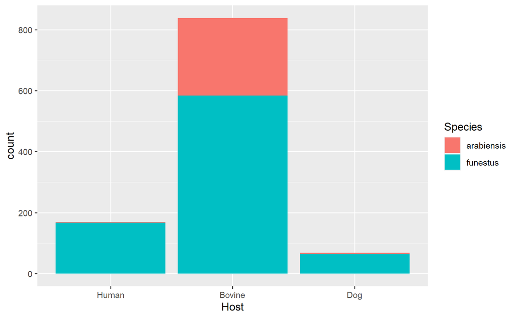

```r
ggplot(sum_df_2_new) +
  aes(x = Host, fill = Species) +
  geom_bar()
```

Chi-square test of independence

For this example, we are going to test if there is a relationship between the variables Species and hosts

```r
chi_test <- chisq.test(table(sum_df_2_new$Species, sum_df_2_new$Host))
chi_test
```

```
    Pearson's Chi-squared test

data:  table(sum_df_2_new$Species, sum_df_2_new$Host)
X-squared = 80.615, df = 2, p-value < 2.2e-16
```

```r
chi_test$expected
```

```
                 Human   Bovine      Dog
  arabiensis  40.71721 201.8995 16.38326
  funestus   128.28279 636.1005 51.61674
```

Using ggbarstats

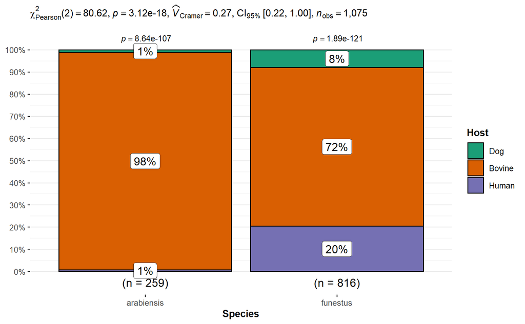

```r
# plot
ggbarstats(
  data = sum_df_2_new,
  x = Host,
  y = Species
) +
  labs(caption = NULL) # remove caption

ggsave("C:/Mannu/Projects/Mannu Phd/GLM_metadata/chi test.png", dpi = 500)
```

Therefore, here we reject the null hypothesis and we conclude that species and hosts are dependent (p-value < 0.001).

We can also store values in tables

```r
library(summarytools)

sum_df_2_new %$%
  ctable(Species, Host,
    prop = "r", chisq = TRUE, headings = FALSE
  ) %>%
  print(
    method = "pander",
    style = "rmarkdown",
    footnote = NA
  )
```

[output not shown]